# IODS course project

Susanna Koivusaari

# Introduction to Open Data Science - Course Project

*This project is a part of the Introduction to Open Data Science (IODS) 2023 course. Here, I will post assignments that I have done during the course.*

# Chapter 1: Start me up!

I came across this course through the university’s email. As I work a lot with large open source data sets and Rstudio, I thought it would be very useful for me. I have almost no experience with GitHub, so especially the part of the course that focuses on using GitHub is new to me.

I have now finished the first chapter of the course. I was surprised how well I already knew most of these themes – only the functions in the lubridate package were more unfamiliar to me. However, I also learned some new tricks, e.g. that you can rename variables within select() function! This was very useful.

I think the Exercise set 1 is a great start for someone who is new to Rstudio. It has all the important functions to get started with processing your own data. The R Markdown syntax was at first a bit difficult to read in R, as I have never seen one before. However, I have read plenty of codes online written in this syntax, so its great to now learn how to make one in your own!

My GitHub repository can be found [here](https://github.com/susannakoivusaari/IODS-project).

# Chapter 2: Regression and model validation

*In this chapter, we will practice regression and model validation with example data.*

We will start by reading in the data that we will be using in this exercise.

```r
# set working directory
setwd("C:/Users/koivusus/IODS/IODS-project_new")

# read in data
data <- read.csv("data/learning_2014_sel_fil.csv")
```

```r
# explore dimensions (number of rows and columns)
dim(data)
```

```
## [1] 166   8
```

```r
# explore structure
str(data)
```

```
## 'data.frame':    166 obs. of  8 variables:
##  $ X       : int  1 2 3 4 5 6 7 8 9 10 ...
##  $ gender  : chr  "F" "M" "F" "M" ...
##  $ age     : int  53 55 49 53 49 38 50 37 37 42 ...
##  $ attitude: int  37 31 25 35 37 38 35 29 38 21 ...
##  $ deep    : num  3.58 2.92 3.5 3.5 3.67 ...
##  $ stra    : num  3.38 2.75 3.62 3.12 3.62 ...
##  $ surf    : num  2.58 3.17 2.25 2.25 2.83 ...
##  $ points  : int  25 12 24 10 22 21 21 31 24 26 ...
```

```r
# remove unnecessary X column
data <- dplyr::select(data, !X)
```

Most of the variables in the data are relatively normally distributed. The clearest exception is age – the study was clearly focused on people around their twenties. Furthermore, a larger portion of the study persons were women. Out of all the variables, attitude towards statistics seems to be most strongly correlated with exam points. The size and direction of the correlation between variables between genders is otherwise pretty equal, except for age: for men, increase in age seems to affect the exam points negatively, whereas in women the effect is non significant.

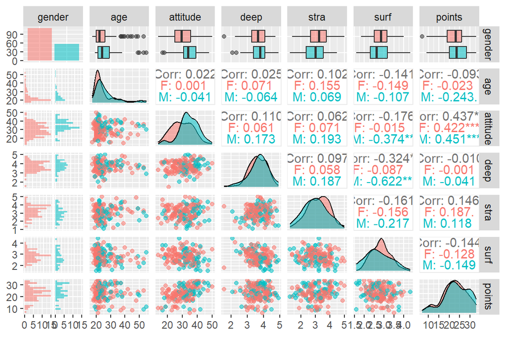

```r
# install (if not yet installed) and load library
# install.packages("ggplot2")
# install.packages("GGally")
library(ggplot2)
library(GGally)
# create a plot matrix with ggpairs()
ggpairs(data, mapping = aes(col = gender, alpha = 0.3), lower = list(combo = wrap("facethist", bins = 20)))
```

```r
# print summaries
summary(data)
```

```
##     gender               age           attitude          deep
##  Length:166         Min.   :17.00   Min.   :14.00   Min.   :1.583
##  Class :character   1st Qu.:21.00   1st Qu.:26.00   1st Qu.:3.333
##  Mode  :character   Median :22.00   Median :32.00   Median :3.667
##                     Mean   :25.51   Mean   :31.43   Mean   :3.680
##                     3rd Qu.:27.00   3rd Qu.:37.00   3rd Qu.:4.083
##                     Max.   :55.00   Max.   :50.00   Max.   :4.917
##       stra            surf           points
##  Min.   :1.250   Min.   :1.583   Min.   : 7.00
##  1st Qu.:2.625   1st Qu.:2.417   1st Qu.:19.00
##  Median :3.188   Median :2.833   Median :23.00
##  Mean   :3.121   Mean   :2.787   Mean   :22.72
##  3rd Qu.:3.625   3rd Qu.:3.167   3rd Qu.:27.75
##  Max.   :5.000   Max.   :4.333   Max.   :33.00
```

Next, we choose three variables, that are the most strongly correlated with exam points and fit a linear regression model using exam points as response variable. As suspected based on the correlations we calculated earlier, attitude had statistically significant effect on exam points. Variables “stra” and “surf” however did not have statistically significant effect on exam points so let’s remove them from the model.

```r
# fit a model with three
model <- lm(points ~ attitude + stra + surf, data = data)

# print out summary
summary(model)
```

```
##
## Call:
## lm(formula = points ~ attitude + stra + surf, data = data)
##
## Residuals:
##      Min       1Q   Median       3Q      Max
## -17.1550  -3.4346   0.5156   3.6401  10.8952
##
## Coefficients:
##             Estimate Std. Error t value Pr(>|t|)
## (Intercept) 11.01711    3.68375   2.991  0.00322 **
## attitude     0.33952    0.05741   5.913 1.93e-08 ***
## stra         0.85313    0.54159   1.575  0.11716
## surf        -0.58607    0.80138  -0.731  0.46563
## ---
## Signif. codes:  0 '***' 0.001 '**' 0.01 '*' 0.05 '.' 0.1 ' ' 1
##
## Residual standard error: 5.296 on 162 degrees of freedom
## Multiple R-squared:  0.2074, Adjusted R-squared:  0.1927
## F-statistic: 14.13 on 3 and 162 DF,  p-value: 3.156e-08
```

```r
# fit a model with three
model1 <- lm(points ~ attitude, data = data)

# print out summary
summary(model1)
```

```
##
## Call:
## lm(formula = points ~ attitude, data = data)
##
## Residuals:
##      Min       1Q   Median       3Q      Max
## -16.9763  -3.2119   0.4339   4.1534  10.6645
##
## Coefficients:
##             Estimate Std. Error t value Pr(>|t|)
## (Intercept) 11.63715    1.83035   6.358 1.95e-09 ***
## attitude     0.35255    0.05674   6.214 4.12e-09 ***
## ---
## Signif. codes:  0 '***' 0.001 '**' 0.01 '*' 0.05 '.' 0.1 ' ' 1
##
## Residual standard error: 5.32 on 164 degrees of freedom
## Multiple R-squared:  0.1906, Adjusted R-squared:  0.1856
## F-statistic: 38.61 on 1 and 164 DF,  p-value: 4.119e-09
```

The main assumptions of a Linear regression model are 1) that the spread of the residuals is roughly the same across all values of the independent variable (i.e. homoscedasticity), and that 2) the residuals are normally distribution. In addition to this, the model results can be affected by outlier observations, wherefore it is important to assess whether there are any potential ones in the data.

Let’s check how well out model satisfies these assumptions using the plot() function. The first plot (Residuals vs. Fitted values) tells us about the homoscedasticity of the model. As there are no clear trends visible in the plot (the points are quite randomly distributed) we can assume that the variance is roughly the same across the data. The second plot (Normal QQ) tells us about the normality assumption: the data seems to follow the line nicely, and therefore the residuals can be assumed to be normally distributed. The third plot (Residuals vs. Leverage) allows us to assess any outlier observations. There are few points that lie quite far away from the horizontal and vertical lines. Therefore, it may be a good idea to try to remove these points from the data and assess the model again to see if anything changes.

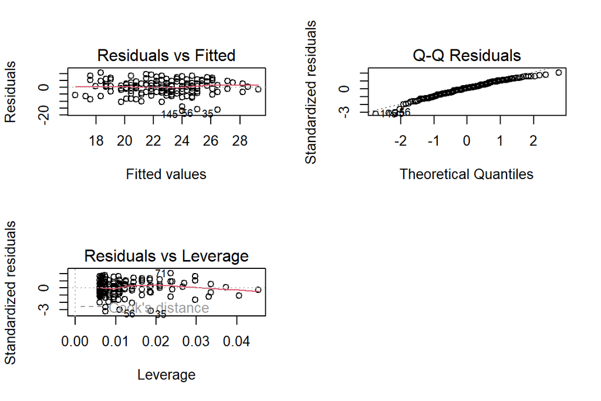

```r
# draw diagnostic plots using the plot() function. Choose the plots 1, 2 and 5
par(mfrow = c(2,2))
plot(model1, which = c(1,2,5))
```

# Chapter 3: Logistic regression

*In this chapter, we will practice logistic regression and model validation with example data.*

```r
# set working directory
setwd("C:/Users/koivusus/IODS/IODS-project_new")

# read in data
data <- read.csv("data/alc.csv")

# print out the column names
colnames(data)
```

```
##  [1] "X"          "school"     "sex"        "age"        "address"
##  [6] "famsize"    "Pstatus"    "Medu"       "Fedu"       "Mjob"
## [11] "Fjob"       "reason"     "guardian"   "traveltime" "studytime"
## [16] "schoolsup"  "famsup"     "activities" "nursery"    "higher"
## [21] "internet"   "romantic"   "famrel"     "freetime"   "goout"
## [26] "Dalc"       "Walc"       "health"     "failures"   "paid"
## [31] "absences"   "G1"         "G2"         "G3"         "alc_use"
## [36] "high_use"
```

```r
# check dimensions
dim(data)
```

```
## [1] 370  36
```

My aim is to investigate which variables explain the high/low alcohol consumption in students. More specifically, I am interested in whether students gender (sex), student’s home address type (address), family educational support (famsup) and attended nursery scool (nursery) explain the high/low alcohol consumption.

I hypothesize that it is more likely that a student belongs to the group of high alcohol consumption if 1) the student is male (males may be more prone to use high alcohol doses), 2) the student lives in a rural area (in rural areas high alcohol consumption may be more common than in urban areas because e.g. other substances may play a bigger part), 3) the student has lower family educational support (lower family educational support may cause students e.g. to feel depressed), 4) the student has not attended nursery school (not as much knowledge about the health effects of alcohol).

Next, we will explore the distributions of the chosen variables and their relationships with alcohol consumption. Let’s first produce a barplot of each variable. Looks like they are all binary.

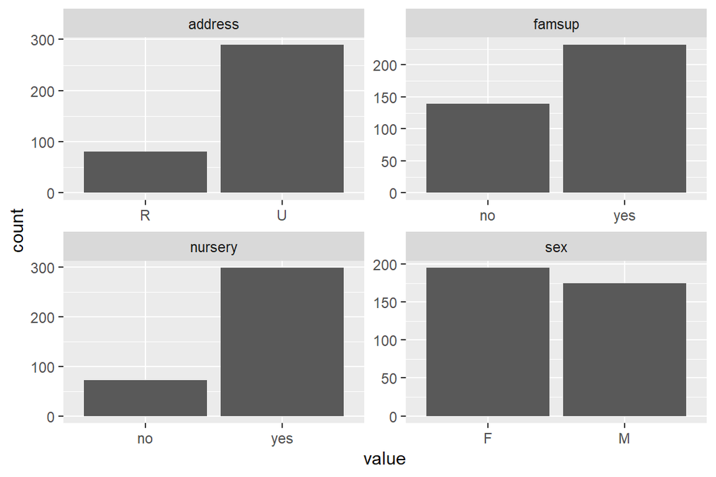

```r
# load library
library(ggplot2)
library(tidyr)
library(dplyr)
# draw a bar plot of each variable
data %>% select(sex, address, famsup, nursery) %>% gather() %>% ggplot(aes(value)) + facet_wrap("key", scales = "free") + geom_bar()
```

Let’s do some cross-tabulations. As I hypothesized, the percent of high alcohol consumption students higher in men than in women. The percent of high alcohol consumption students is also higher in students living in rural areas, in students with no family educational support and within students that have not attended nursery school. All results so far therefore support my hypotheses.

```r
# see how many percent in men and in women belong to the high/low alcohol consumption class
data %>% group_by(sex, high_use) %>% summarise(count = n()) %>% mutate(prop = count / sum(count))
```

[output not shown]

```
## # A tibble: 4 × 4
## # Groups:   sex [2]
##   sex   high_use count  prop
##   <chr> <lgl>    <int> <dbl>
## 1 F     FALSE      154 0.790
## 2 F     TRUE        41 0.210
## 3 M     FALSE      105 0.6
## 4 M     TRUE        70 0.4
```

```r
# see how many percent in students living in urban/rural areas belong to the high/low alcohol consumption class
data %>% group_by(address, high_use) %>% summarise(count = n()) %>% mutate(prop = count / sum(count))
```

```
## # A tibble: 4 × 4
## # Groups:   address [2]
##   address high_use count  prop
##   <chr>   <lgl>    <int> <dbl>
## 1 R       FALSE       50 0.617
## 2 R       TRUE        31 0.383
## 3 U       FALSE      209 0.723
## 4 U       TRUE        80 0.277
```

```r
# see how many percent in students that have received family educational support belong to the high/low alcohol consumption class
data %>% group_by(famsup, high_use) %>% summarise(count = n()) %>% mutate(prop = count / sum(count))
```

```
## # A tibble: 4 × 4
## # Groups:   famsup [2]
##   famsup high_use count  prop
##   <chr>  <lgl>    <int> <dbl>
## 1 no     FALSE       94 0.676
## 2 no     TRUE        45 0.324
## 3 yes    FALSE      165 0.714
## 4 yes    TRUE        66 0.286
```

```r
# see how many percent in students that have or have not attended nursery education belong to the high/low alcohol consumption class
data %>% group_by(nursery, high_use) %>% summarise(count = n()) %>% mutate(prop = count / sum(count))
```

```
## # A tibble: 4 × 4
## # Groups:   nursery [2]
##   nursery high_use count  prop
##   <chr>   <lgl>    <int> <dbl>
## 1 no      FALSE       46 0.639
## 2 no      TRUE        26 0.361
## 3 yes     FALSE      213 0.715
## 4 yes     TRUE        85 0.285
```

To further analyze the relationship between the chosen variables, I will run a logistic regression model.

The summary of the model shows that only variables “sex” and “address” had statistical relationships with alcohol consumption, with the p-value of address being only 0.09. The coefficient of 0.916651 for the “sexM” variable suggests that being male (sexM) is associated with an increase in the log-odds of the response variable being TRUE (high_use) by 0.916651. The coefficient of -0.459666 for the “addressU” variable suggests that having an address of “U” (Urban area) is associated with a decrease in the log-odds of the response variable being TRUE (high_use) by 0.459666.

Next, we will look closer into the odds ratios, which quantify the strength of the relationship between dependent and independent variables. The results can be interpreted so that if OR = 1, the odds of high_use being TRUE or FALSE are the same, regardless of the dependent variable. On other words, odds ratio values that are other than 1 have some kind of effect on the response variable. Thus, for all other variables than sex, the condifence interval includes the value 1, suggesting that only sex has statistically significant effects on the odds of high_use being TRUE or FALSE.

```r
# find a model
mod1 <- glm(high_use ~ sex + address + famsup + nursery, data = data, family = "binomial")

# print summary
summary(mod1)
```

```
##
## Call:
## glm(formula = high_use ~ sex + address + famsup + nursery, family = "binomial",
##     data = data)
##
## Coefficients:
##              Estimate Std. Error z value Pr(>|z|)
## (Intercept) -0.716933   0.374261  -1.916 0.055416 .
## sexM         0.916651   0.238880   3.837 0.000124 ***
## addressU    -0.459666   0.271096  -1.696 0.089965 .
## famsupyes   -0.002989   0.243205  -0.012 0.990194
## nurseryyes  -0.316908   0.285996  -1.108 0.267824
## ---
## Signif. codes:  0 '***' 0.001 '**' 0.01 '*' 0.05 '.' 0.1 ' ' 1
##
## (Dispersion parameter for binomial family taken to be 1)
##
##     Null deviance: 452.04  on 369  degrees of freedom
## Residual deviance: 431.82  on 365  degrees of freedom
## AIC: 441.82
##
## Number of Fisher Scoring iterations: 4
```

```r
# compute odds ratios (OR)
OR <- coef(mod1) %>% exp

# compute confidence intervals (CI)
CI <- confint(mod1) %>% exp
# print out the odds ratios with their confidence intervals
cbind(OR, CI)
```

```
##                    OR     2.5 %   97.5 %
## (Intercept) 0.4882475 0.2314463 1.008482
## sexM        2.5009003 1.5729358 4.019096
## addressU    0.6314946 0.3723072 1.080690
## famsupyes   0.9970153 0.6209114 1.613621
## nurseryyes  0.7283975 0.4181094 1.287680
```

Let’s fit the model again with the variable that had statistically significant effect on alcohol consumption (sex) and investigate the predictive power of the model.

According to the cross tabulation of predictions versus actual values, rows that had actual value FALSE were predicted to be FALSE by the model 259 times (70 %), whereas actual values TRUE were predicted as FALSE 111 times (30 %). In other words, the model predicted FALSE for all actual values. Thus, the model maybe works a bit bettew than simply guessing in which class a person belongs.

```r
# fit a model with only the variables that had statistical relationship with alcohol consumption
mod2 <- glm(high_use ~ sex, data = data, family = "binomial")

# predict() the probability of high_use
probabilities <- predict(mod2, type = "response")

# add the predicted probabilities to 'alc'
data <- mutate(data, probability = probabilities)

# use the probabilities to make a prediction of high_use
data <- mutate(data, prediction = probability > 0.5)

# see the last ten original classes, predicted probabilities, and class predictions
select(data, sex, high_use, probability, prediction) %>% tail(10)
```

```
##     sex high_use probability prediction
## 361   M    FALSE   0.4000000      FALSE
## 362   M    FALSE   0.4000000      FALSE
## 363   M     TRUE   0.4000000      FALSE
## 364   F    FALSE   0.2102564      FALSE
## 365   F    FALSE   0.2102564      FALSE
## 366   F    FALSE   0.2102564      FALSE
## 367   F    FALSE   0.2102564      FALSE
## 368   F    FALSE   0.2102564      FALSE
## 369   M     TRUE   0.4000000      FALSE
## 370   M     TRUE   0.4000000      FALSE
```

```r
# tabulate the target variable versus the predictions
table(high_use = data$high_use, prediction = data$prediction) # prediction produced FALSE to all study persons
```

```
##         prediction
## high_use FALSE
##    FALSE   259
##    TRUE    111
```

```r
# print the table in percentages
prop.table(table(high_use = data$high_use, prediction = data$prediction)) * 100
```

```
##         prediction
## high_use FALSE
##    FALSE    70
##    TRUE     30
```

```r
# define a loss function (mean prediction error)
loss_func <- function(class, prob) {
  n_wrong <- abs(class - prob) > 0.5
  mean(n_wrong)
}

# load library
library(boot)
# K-fold cross-validation
cv <- cv.glm(data = data, cost = loss_func, glmfit = mod2, K = 10)

# average number of wrong predictions in the cross validation
cv$delta[1]
```

```
## [1] 0.3
```